# Weekly Energy Charts

November 18, 2022

Sign up to receive our email updates via [Substack](https://leach.substack.com/)

[interactive chart not shown]

# Featured Stories

## Largest Flow Battery in the World

#### [Yousaff Habib](https://www.linkedin.com/in/yousaff-habib-6684891a5/)

For this weeks chart, I have some interesting news that ties into one of my previous stories. You may recall my chart on vanadium flow batteries and their potential usefulness in renewable energy storage. Last month, the Chinese city of Dalian switched on the Dalian Flow Battery Energy Storage Peak-shaving Power Station, a power bank for the city, boasting an initial capacity of 400MWh and an output of 100MW. There are plans to scale the battery up to a 200MW output and 800MWh capacity. The battery aims to reduce peaks and valleys by storing energy, increasing grid reliability in the region. As I’ve mentioned in past charts, China is taking big steps to be energy independent, and the continual innovation and adoption of new technologies has allowed them to iterate on their work. While the idea is nothing new, the use of a vanadium flow battery this large is a promising sign that the technology will see more widespread adoption. Considering that lithium supplies are beginning to [see strain](https://www.weforum.org/agenda/2022/07/electric-vehicles-world-enough-lithium-resources/), it may be the very thing we need to progress with renewable. To read more about the Dalian Flow Battery, check out [this](https://newatlas.com/energy/worlds-largest-flow-battery-grid-china/) article.

## OPEC vs. IEA - Who to believe?

#### [Erica Beattie](https://www.linkedin.com/in/erica-beattie-594b471a1/?originalSubdomain=ca)

The Organization of Petroleum Exporting Countries (OPEC) and the International Energy Agency (IEA) are two of the largest international energy organizations. Each year, they both create extensive forecasts about the future of oil and energy; titled [World Oil Outlook (WOO)](https://woo.opec.org/chapter.php?chapterNr=311) for OPEC and [World Energy Outlook (WEO)](https://www.iea.org/reports/world-energy-outlook-2022/executive-summary) for IEA. Their documents for 2022 have recently been released. While one would assume the information presented in each would be relatively similar, given they both “speak for the same planet”, [this article](https://energynow.ca/2022/11/david-yager-iea-versus-opec-opposing-views-on-the-future-of-energy-and-the-world/) points out some discrepancies in outlooks and approaches.

In such a turbulent and ever-changing world, faced with war and energy shortages, it may become difficult to know who to believe.

## Oil’s no good very bad week

#### [Andrew Leach](https://linkedin.com/leach-econ)

[figure not shown]

Want to impress your friends? Sound smart to your profs? Or just learn the oil market lingo? Subscribe to Rory’s [Substack](https://www.commoditycontext.com/p/ocw-46w22) and get his weekly summaries in your inbox.

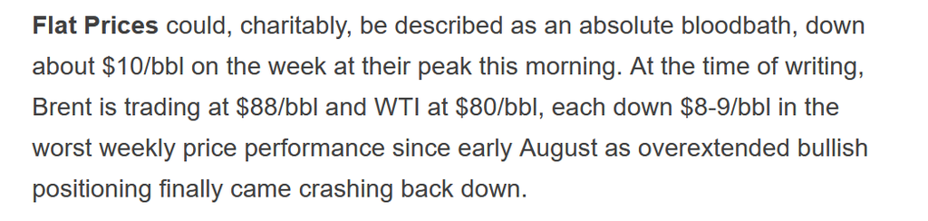

# Oil

## Weekly Crude Prices

### Feature Crude

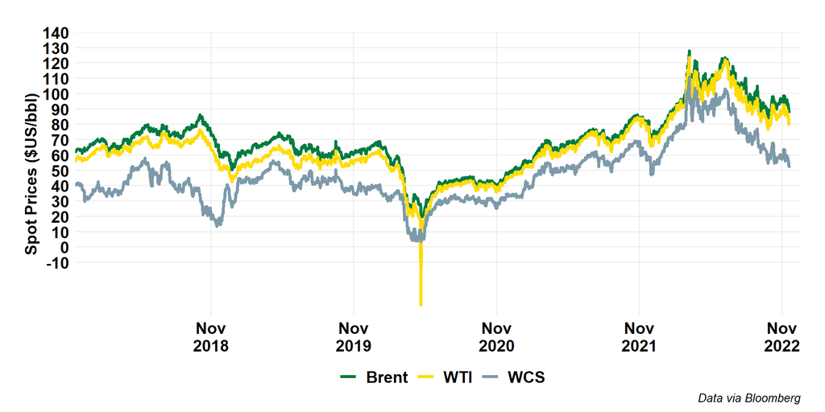

### Alberta Crude

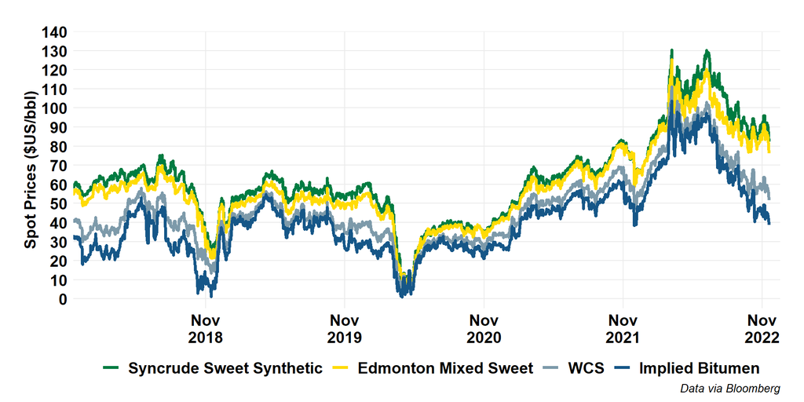

### Alberta Crude (Short)

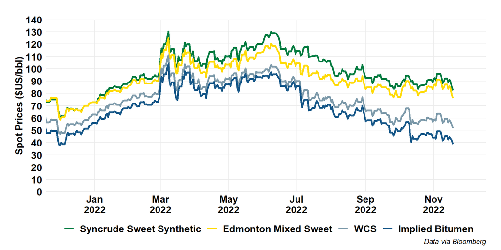

### US Crude

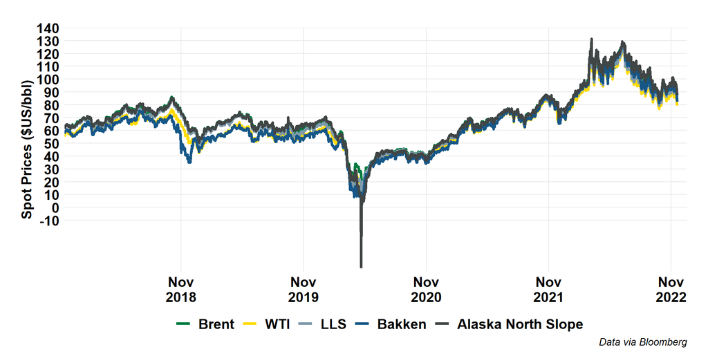

### Global Crude

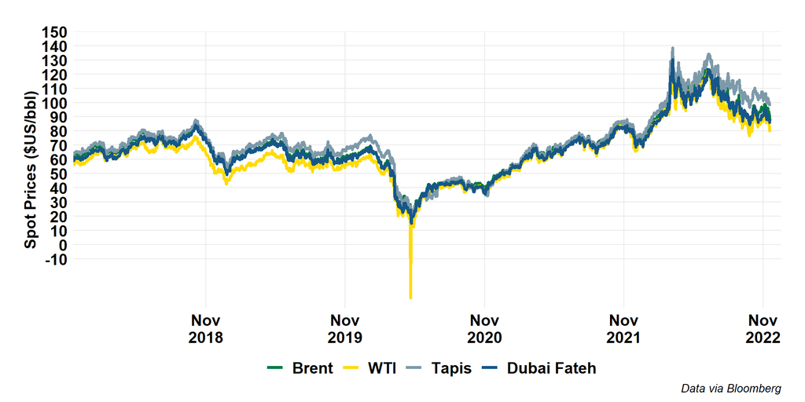

## Oil Price Differentials

### Brent-WTI

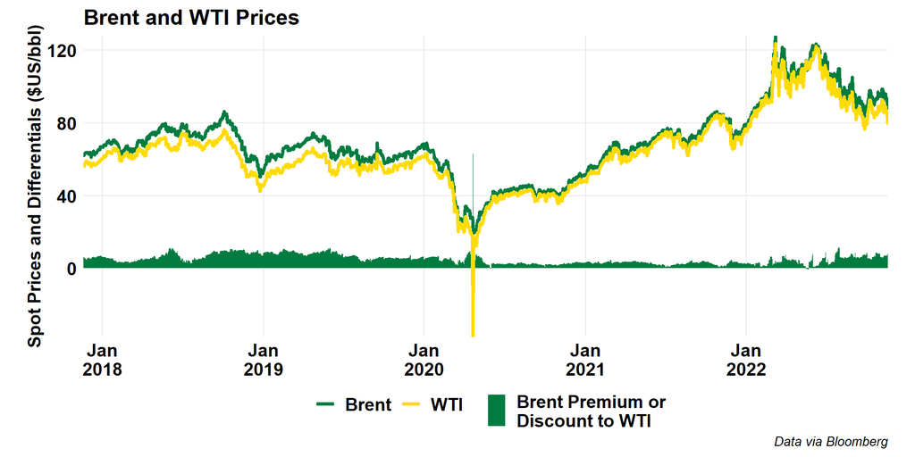

### WTI-WCS

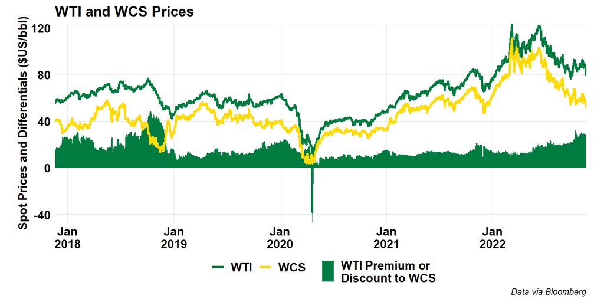

### WTI-WCS (Short)

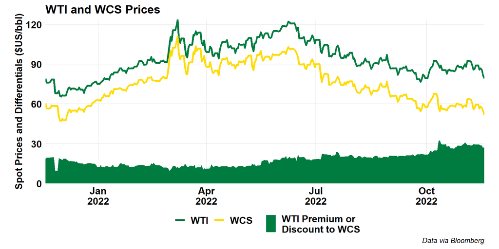

### Maya-WCS

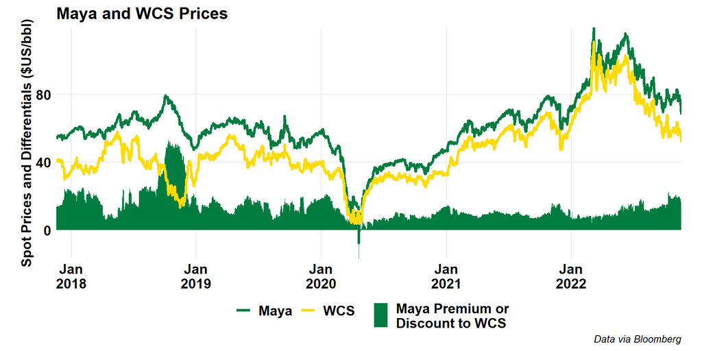

### WTI Cushing vs MEH

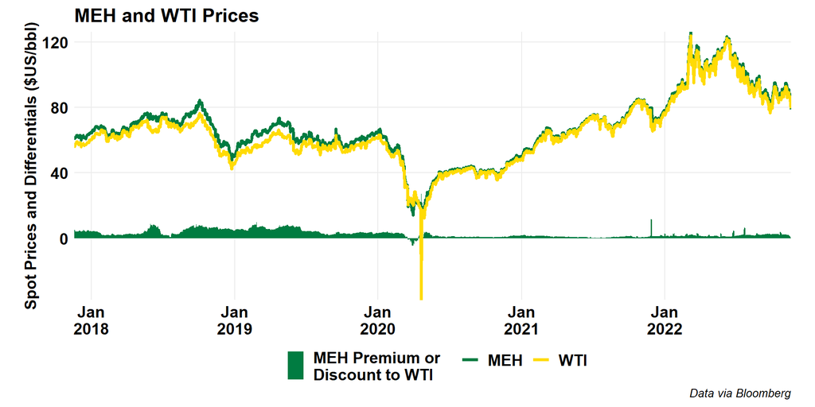

## Forward Curves

### WTI

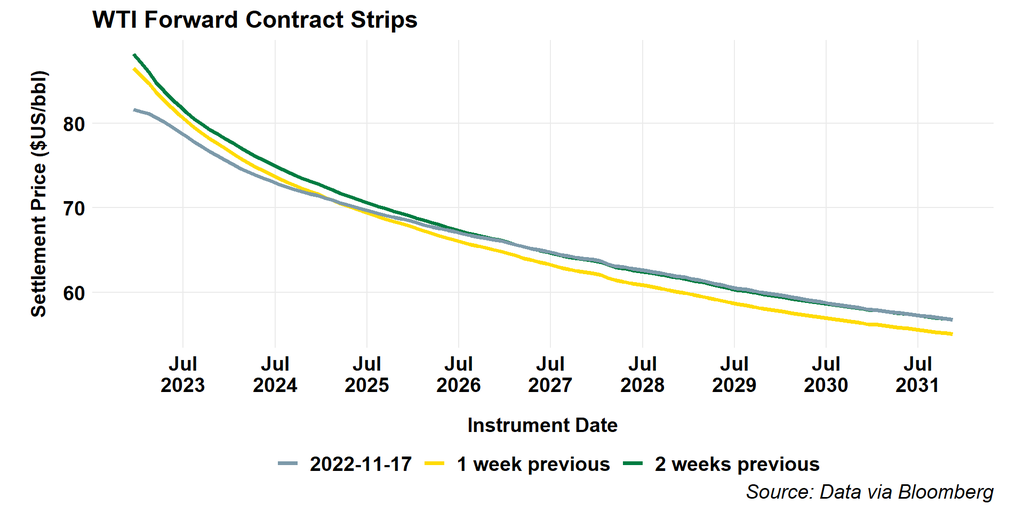

### Brent

[figure not shown]

## Canadian Crude Supply and Disposition

### Canadian Production

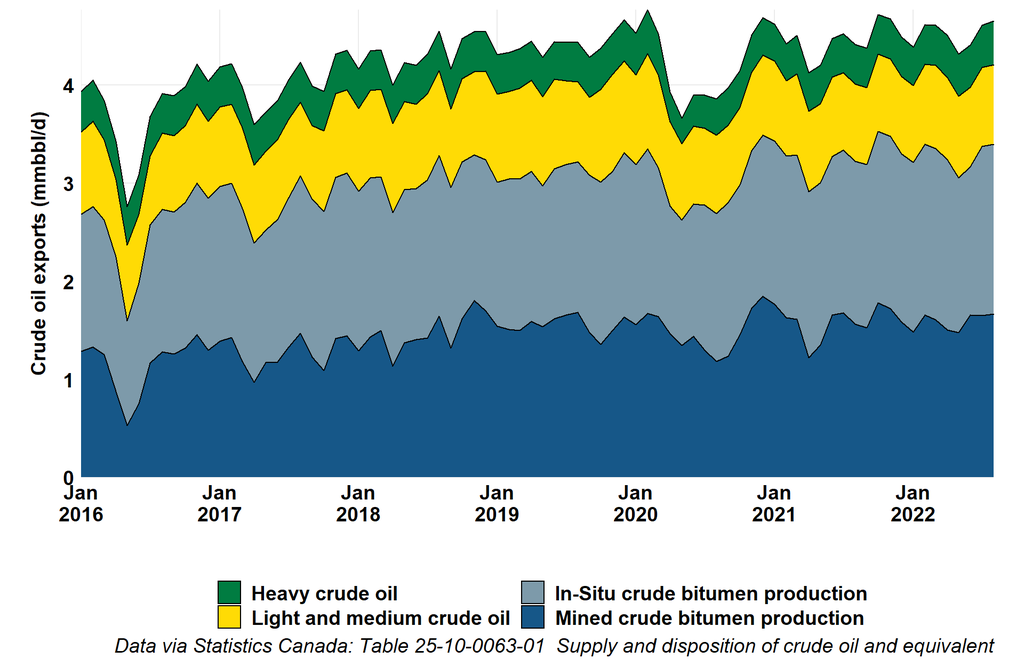

### Alberta Production

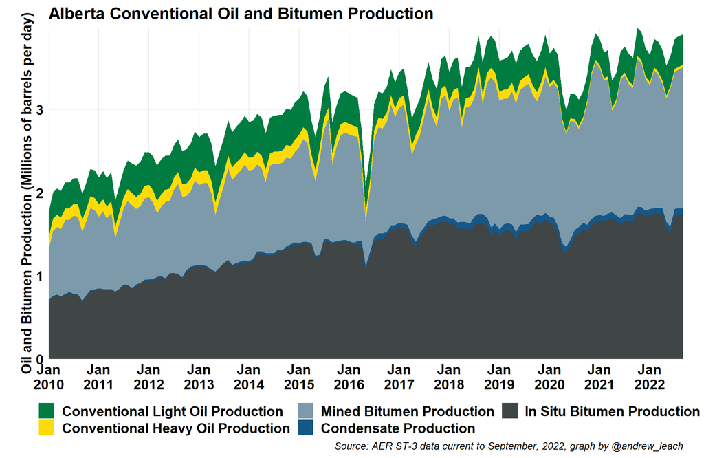

### Imports

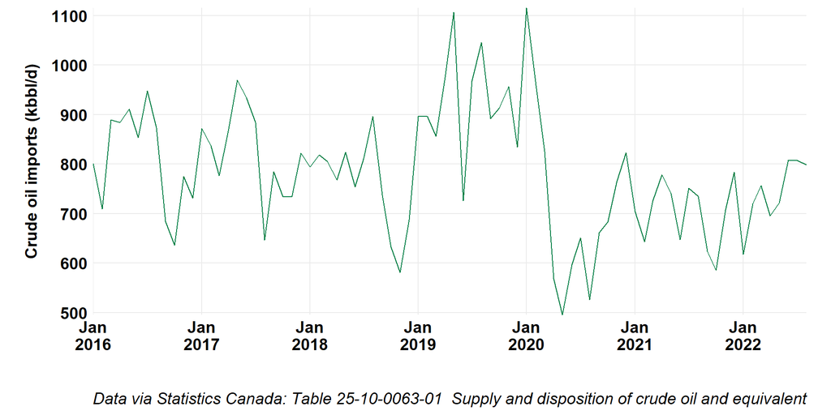

### Exports

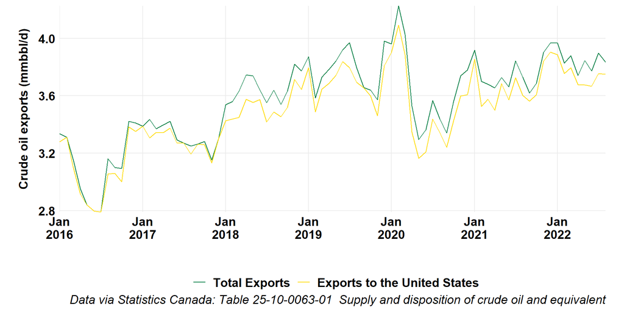

### Exports by Rail

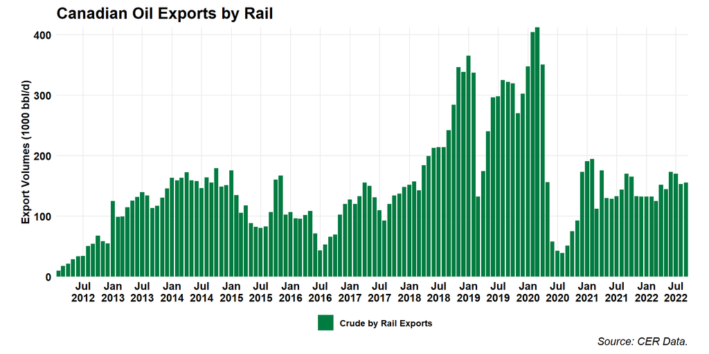

## US Oil

### Production

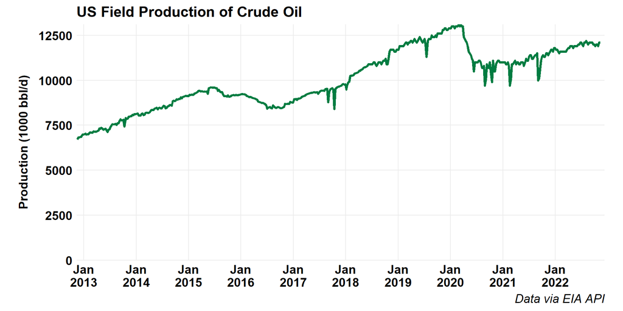

### LTO Production by Play

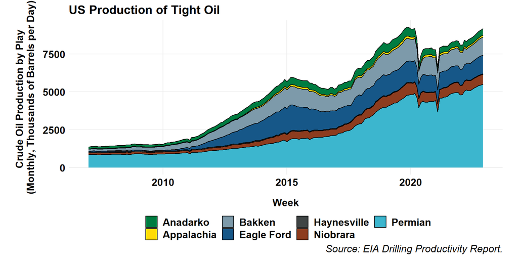

### Net Imports

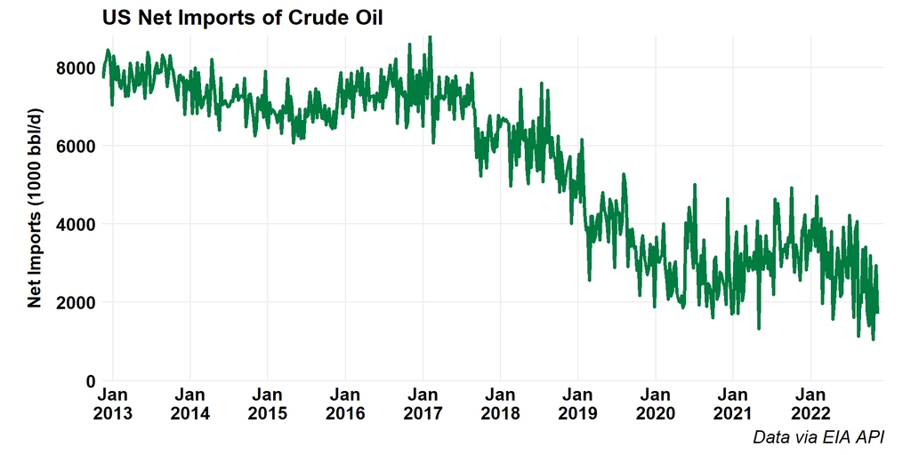

### Oil and Product Net Imports

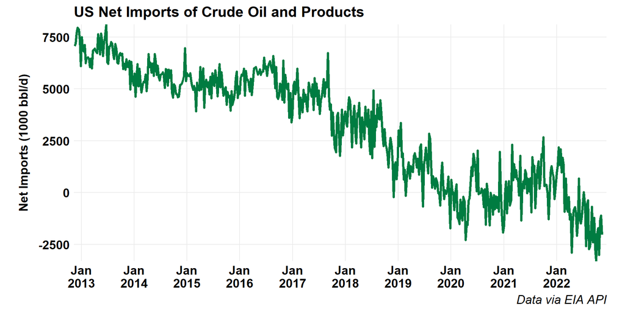

### Inventories

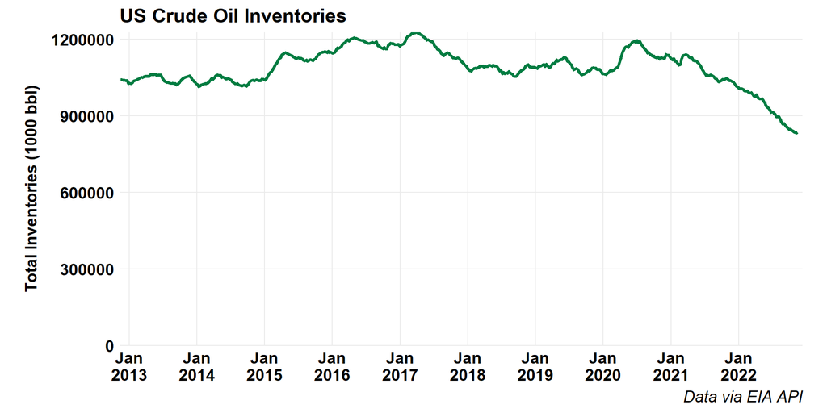

### EIA STEO Forecasts

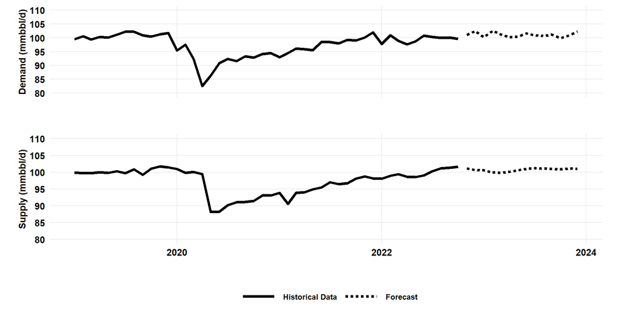

# Refined Products

## Canadian Gasoline Prices

### Map

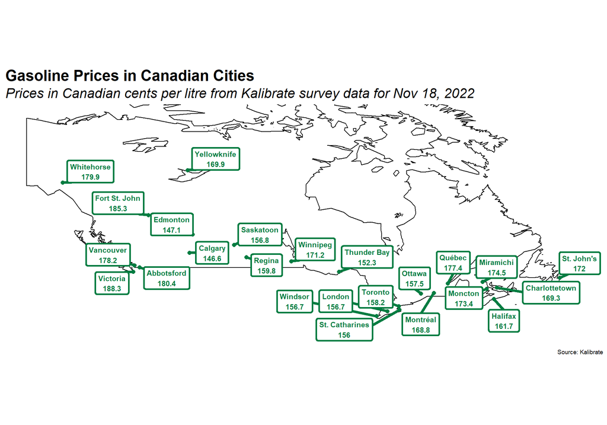

### Historic Gasoline Prices

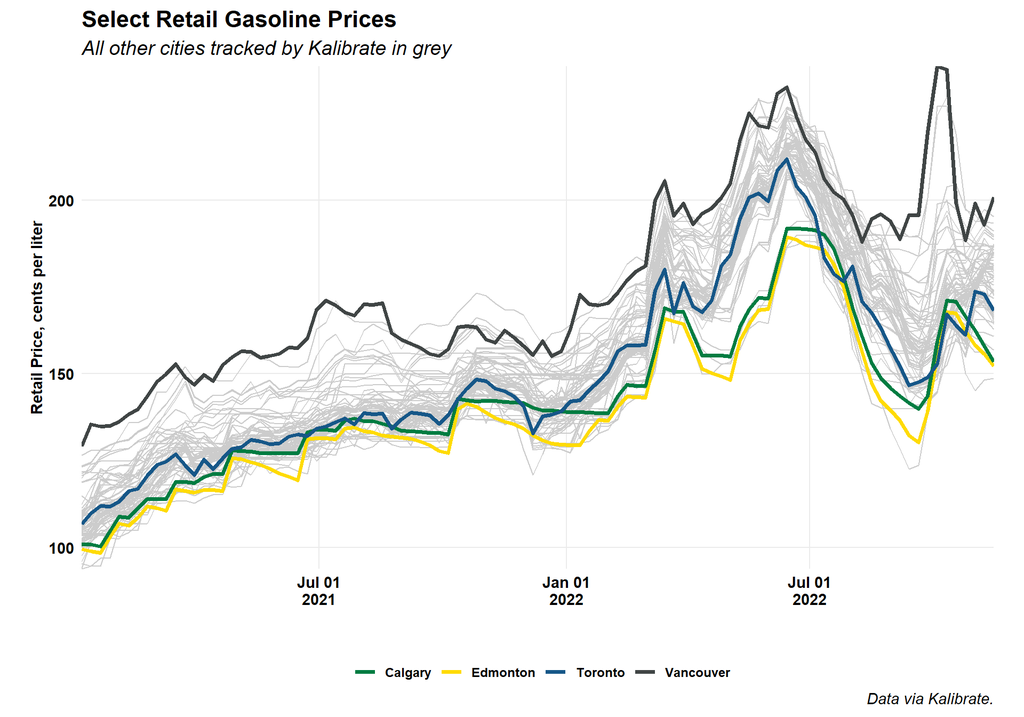

### Gasoline Prices in BTC

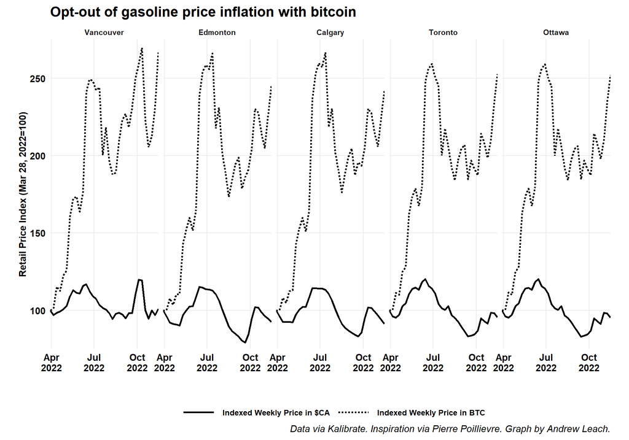

### Historic Diesel Prices

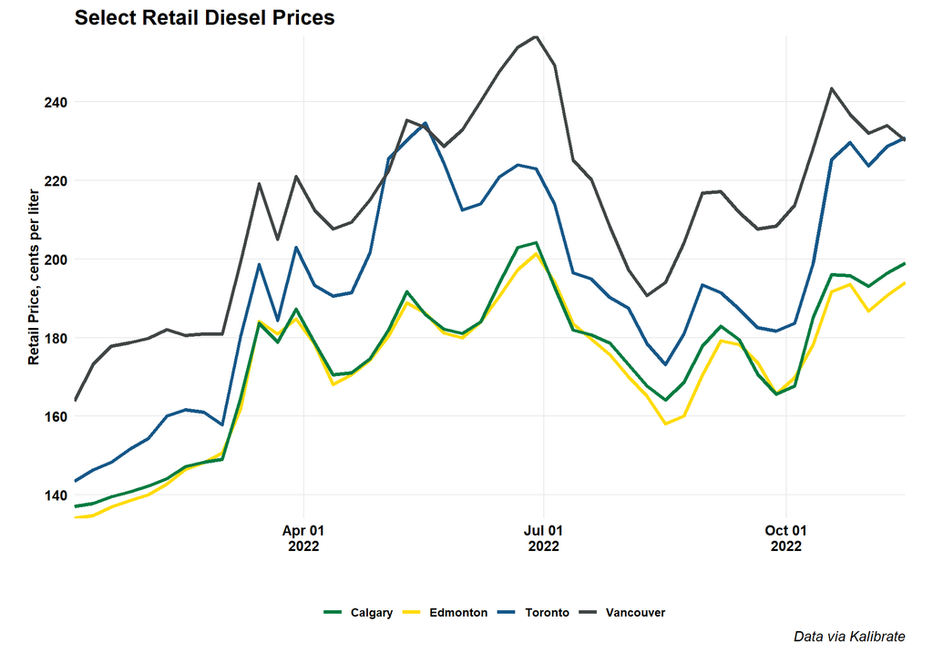

### Diesel Prices in BTC

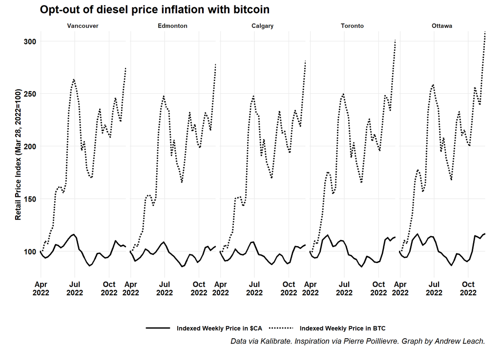

## Canadian Refinery Runs

### Canadian Refinery Runs

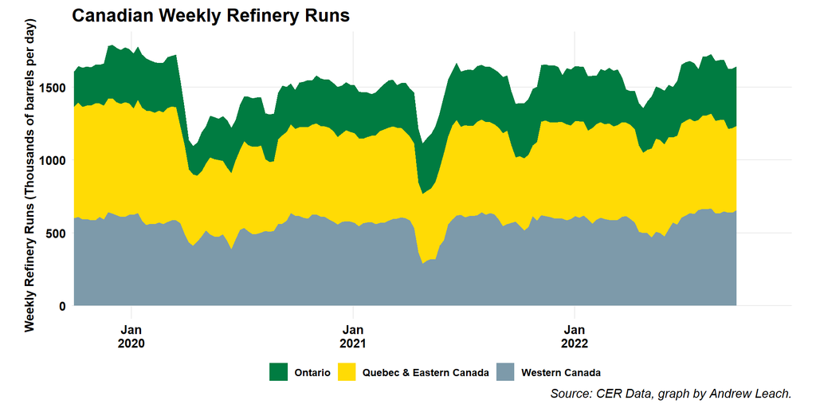

### Western Canada Refinery Runs

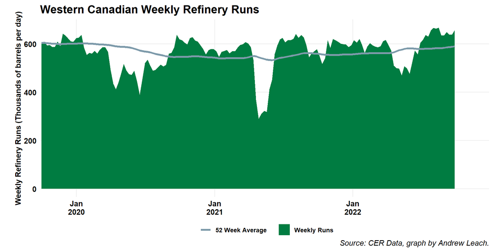